# Case_Study

```r
#Alle Packages
if(!require(tidyverse)){
  install.packages("tidyverse")
  require(tidyverse)
}
if(!require(lubridate)){
  install.packages("lubridate")
  require(lubridate)
}
if(!require(scales)){
  install.packages("scales")
  require(scales)
}
if(!require(ggthemes)){
  install.packages("ggthemes")
  require(ggthemes)
}
if(!require(RColorBrewer)){
  install.packages("RColorBrewer")
  require(RColorBrewer)
}
```

## Gliederung und Methodisches Vorgehen

Um heraus zu finden, welche Fahrzeuge kritische Einzelteile oder Komponenten enthalten, wird zuerst auf Einzelteilebene nach fehlerhaften Einzelteilen gesucht. Daraufhin schließt sich die Suche nach fehlerhaften Komponenten an.

**Analyseprozess:**

1. Funktionen zur Überprüfung des Datensatzes
2. Analyse Einzelteile
- Clean Data and Tidy Data
- Understand - fehlerhafte Einzelteile
- Visualisierung der fehlerhaften Einzelteile
- Lieferantenanalyse
3. Analyse Komponenten
- Clean Data and Tidy Data
- Kritische Komponten
4. Analyse Fahrzeuge
- Clean Data and Tidy Data
- Fahrzeuge mit kritischen Komponenten
5. Zulassung und Geodaten
- Clean Data and Tidy Data
- Finaler Datensatz
- Visualisierung
6. Export des finalen Datensatzes

## 1.Funktionen

Um einen ersten Überblick über die Datensätze zu erlangen, verwenden wir die Funktion firstGlance(). Mit der Funktion NATest() wird gezählt, wie viele NAs in den jeweiligen Spalten eines Datensatzes vorkommen.

### Funktion für Überblick über Dataframes

```r
  firstGlance <- function(x){
    print(summary(x))
    cat("\n")
    print(str(x))
    cat("\n")
    print(head(x))
    cat("\n")
    print(tail(x))
  }
```

### Funktion für NA Überprüfung

```r
  NATest <- function(x){
    if(any(is.na(x))){
      for(i in 1:ncol(x)){
        if (nrow(x[is.na(x[i]),]) > 0){
          print(paste(nrow(x[is.na(x[i]),]), "NA´s in", names(x[i])))
        }
      }
    }else{
      print("Es existieren keine NA´s.")
    }
  }
```

## 2.Analyse der Einzelteile

### Import

Zunächst müssen die einzelnen Tabellen der Einzelteile importiert werden, wobei auf die Zeilen und Reihentrennung(Komma o. Semikolon) zu achten ist.

```r
  T11 <- read.csv2("Einzelteil_T11.csv", stringsAsFactors = FALSE)
  T14 <- read.csv2("Einzelteil_T14.csv", stringsAsFactors = FALSE)
  T15 <- read.csv2("Einzelteil_T15.csv", stringsAsFactors = FALSE)
  T16 <- read.csv("Einzelteil_T16.csv", stringsAsFactors = FALSE)
  T19 <- read.csv("Einzelteil_T19.csv", stringsAsFactors = FALSE)
  T20 <- read.csv2("Einzelteil_T20.csv", stringsAsFactors = FALSE)
```

### Clean Data und Tidy Data

Nachfolgend werden alle Einzelteiltabellen mit der firstGlance() und NATest() Funktion überprüft und Unstimmigkeiten behoben. Vorher wird allgemein der Aufbau der Einzelteile-Datensätze verglichen, um prinzipiell einheitliche Tabellen zu erzeugen.

#### Allgemeiner Aufbau der Einzelteile-Datensätze - Vergleich

```r
head(T11)
```

```
##   X      IDNummer Produktionsdatum Herstellernummer Werksnummer Fehlerhaft
## 1 1 11-212-2121-1       2008-11-07              212        2121          0
## 2 2 11-212-2121-2       2008-11-07              212        2121          0
## 3 3 11-212-2121-3       2008-11-07              212        2121          0
## 4 4 11-212-2121-4       2008-11-07              212        2121          0
## 5 5 11-212-2121-5       2008-11-07              212        2121          0
## 6 6 11-212-2121-6       2008-11-07              212        2121          0
```

```r
head(T14)
```

```
##   X      IDNummer Produktionsdatum Herstellernummer Werksnummer Fehlerhaft
## 1 1 14-213-2132-1       2008-11-07              213        2132          0
## 2 2 14-213-2132-2       2008-11-07              213        2132          0
## 3 3 14-213-2132-3       2008-11-07              213        2132          0
## 4 4 14-213-2132-4       2008-11-07              213        2132          0
## 5 5 14-213-2132-5       2008-11-07              213        2132          0
## 6 6 14-213-2132-6       2008-11-07              213        2132          0
```

```r
head(T15)
```

```
##   X      IDNummer Wareneingangsdatum Herstellernummer Werksnummer
## 1 1 15-209-2093-1         12.11.2008              209        2093
## 2 2 15-209-2093-2         12.11.2008              209        2093
## 3 3 15-209-2093-3         12.11.2008              209        2093
## 4 4 15-209-2093-4         12.11.2008              209        2093
## 5 5 15-209-2093-5         15.11.2008              209        2093
## 6 6 15-209-2093-6         11.11.2008              209        2093
##   Fehlerhaft
## 1          0
## 2          0
## 3          0
## 4          0
## 5          0
## 6          0
```

```r
head(T16)
```

```
##   X1      IDNummer Produktionsdatum Herstellernummer Werksnummer
## 1  1 16-212-2121-1            14190              212        2121
## 2  2 16-212-2121-2            14190              212        2121
## 3  3 16-212-2121-3            14190              212        2121
## 4  4 16-212-2121-4            14190              212        2121
## 5  5 16-212-2121-5            14190              212        2121
## 6  6 16-212-2121-6            14190              212        2121
##   Fehlerhaft              Origin
## 1          0 origin = 1970-01-01
## 2          0 origin = 1970-01-01
## 3          0 origin = 1970-01-01
## 4          0 origin = 1970-01-01
## 5          0 origin = 1970-01-01
## 6          0 origin = 1970-01-01
```

```r
head(T19)
```

```
##   X1 IDNummer Produktionsdatum Herstellernummer Werksnummer Fehlerhaft X11
## 1  1     <NA>             <NA>               NA          NA         NA 196
## 2  2     <NA>             <NA>               NA          NA         NA 197
## 3  3     <NA>             <NA>               NA          NA         NA 198
## 4  4     <NA>             <NA>               NA          NA         NA 199
## 5  5     <NA>             <NA>               NA          NA         NA 200
## 6  6     <NA>             <NA>               NA          NA         NA 201
##       IDNummer1 Produktionsdatum1 Herstellernummer1 Werksnummer1
## 1 13-210-2131-1        2008-11-07               215         2154
## 2 13-210-2131-2        2008-11-07               215         2154
## 3 13-210-2131-3        2008-11-07               215         2154
## 4 13-210-2131-4        2008-11-07               215         2154
## 5 13-210-2131-5        2008-11-07               215         2154
## 6 13-210-2131-6        2008-11-07               215         2154
##   Fehlerhaft1
## 1           0
## 2           0
## 3           0
## 4           0
## 5           0
## 6           0
```

```r
head(T20)
```

```
##   X      IDNummer Produktionsdatum Herstellernummer Werksnummer Fehlerhaft
## 1 1 20-211-2111-1       07.11.2008              211        2111          0
## 2 2 20-211-2111-2       07.11.2008              211        2111          0
## 3 3 20-211-2111-3       07.11.2008              211        2111          0
## 4 4 20-211-2111-4       07.11.2008              211        2111          0
## 5 5 20-211-2111-5       07.11.2008              211        2111          0
## 6 6 20-211-2111-6       07.11.2008              211        2111          0
```

Anhand der Spaltennamen & Einträge sieht man, dass für unsere weitere Analyse nur die Spalten 2 bis 6 wichtig sind, alle anderen Spalten werden ausgeschlossen. Dies wird nun bei allen Einzelteile-Datensätzen (außer T19) vorgenommen, um eine einheitliche Struktur zu erzeugen, um später ein problemloses Zusammenführen der einzelnen Tabellen zu einer Gesamttabelle zu ermöglichen. T19 wird gesondert selected, weil die Strutur hier allgemein nicht in Ordnung ist, Spalten teilweise doppelt existieren etc.

```r
#Auswählen der Spalten 2 bis 6
T11.new <- T11%>%
  select(2:6)
T14.new <- T14%>%
  select(2:6)
T15.new <- T15%>%
  select(2:6)
T16.new <- T16 %>%
  select(2:6)
T20.new <- T20 %>%
  select(2:6)
```

Nun werden die einzelnen Datensätze mit firstGlance() und NATest() untersucht.

#### T11

```r
firstGlance(T11)
```

```
##        X             IDNummer         Produktionsdatum   Herstellernummer
##  Min.   :      1   Length:2385260     Length:2385260     Min.   :212.0
##  1st Qu.: 596316   Class :character   Class :character   1st Qu.:212.0
##  Median :1192631   Mode  :character   Mode  :character   Median :213.0
##  Mean   :1192631                                         Mean   :213.1
##  3rd Qu.:1788945                                         3rd Qu.:213.0
##  Max.   :2385260                                         Max.   :215.0
##   Werksnummer     Fehlerhaft
##  Min.   :2121   Min.   :0.00e+00
##  1st Qu.:2121   1st Qu.:0.00e+00
##  Median :2131   Median :0.00e+00
##  Mean   :2133   Mean   :2.81e-05
##  3rd Qu.:2131   3rd Qu.:0.00e+00
##  Max.   :2154   Max.   :1.00e+00
##
## 'data.frame':    2385260 obs. of  6 variables:
##  $ X               : int  1 2 3 4 5 6 7 8 9 10 ...
##  $ IDNummer        : chr  "11-212-2121-1" "11-212-2121-2" "11-212-2121-3" "11-212-2121-4" ...
##  $ Produktionsdatum: chr  "2008-11-07" "2008-11-07" "2008-11-07" "2008-11-07" ...
##  $ Herstellernummer: int  212 212 212 212 212 212 212 212 212 212 ...
##  $ Werksnummer     : int  2121 2121 2121 2121 2121 2121 2121 2121 2121 2121 ...
##  $ Fehlerhaft      : int  0 0 0 0 0 0 0 0 0 0 ...
## NULL
##
##   X      IDNummer Produktionsdatum Herstellernummer Werksnummer Fehlerhaft
## 1 1 11-212-2121-1       2008-11-07              212        2121          0
## 2 2 11-212-2121-2       2008-11-07              212        2121          0
## 3 3 11-212-2121-3       2008-11-07              212        2121          0
## 4 4 11-212-2121-4       2008-11-07              212        2121          0
## 5 5 11-212-2121-5       2008-11-07              212        2121          0
## 6 6 11-212-2121-6       2008-11-07              212        2121          0
##
##               X           IDNummer Produktionsdatum Herstellernummer
## 2385255 2385255 11-212-2121-712652       2016-11-05              212
## 2385256 2385256 11-212-2121-712653       2016-11-05              212
## 2385257 2385257 11-212-2121-712654       2016-11-05              212
## 2385258 2385258 11-212-2121-712655       2016-11-05              212
## 2385259 2385259 11-212-2121-712656       2016-11-05              212
## 2385260 2385260 11-212-2121-712657       2016-11-05              212
##         Werksnummer Fehlerhaft
## 2385255        2121          0
## 2385256        2121          0
## 2385257        2121          0
## 2385258        2121          0
## 2385259        2121          0
## 2385260        2121          0
```

```r
NATest(T11)
```

```
## [1] "Es existieren keine NA´s."
```

Keine Auffälligkeiten außer, dass Produktionsdatum falschen Datentyp (character) hat -> Umwandlung in Datumsformat.

```r
T11.new$Produktionsdatum <- as.Date(T11$Produktionsdatum, format = "%Y-%m-%d")
```

#### T14

```r
firstGlance(T14)
```

```
##        X            IDNummer         Produktionsdatum   Herstellernummer
##  Min.   :     1   Length:477052      Length:477052      Min.   :213.0
##  1st Qu.:119264   Class :character   Class :character   1st Qu.:213.0
##  Median :238527   Mode  :character   Mode  :character   Median :214.0
##  Mean   :238527                                         Mean   :213.6
##  3rd Qu.:357789                                         3rd Qu.:214.0
##  Max.   :477052                                         Max.   :214.0
##   Werksnummer     Fehlerhaft
##  Min.   :2131   Min.   :0.00e+00
##  1st Qu.:2132   1st Qu.:0.00e+00
##  Median :2141   Median :0.00e+00
##  Mean   :2138   Mean   :3.77e-05
##  3rd Qu.:2143   3rd Qu.:0.00e+00
##  Max.   :2143   Max.   :1.00e+00
##
## 'data.frame':    477052 obs. of  6 variables:
##  $ X               : int  1 2 3 4 5 6 7 8 9 10 ...
##  $ IDNummer        : chr  "14-213-2132-1" "14-213-2132-2" "14-213-2132-3" "14-213-2132-4" ...
##  $ Produktionsdatum: chr  "2008-11-07" "2008-11-07" "2008-11-07" "2008-11-07" ...
##  $ Herstellernummer: int  213 213 213 213 213 213 213 213 213 213 ...
##  $ Werksnummer     : int  2132 2132 2132 2132 2132 2132 2132 2132 2132 2132 ...
##  $ Fehlerhaft      : int  0 0 0 0 0 0 0 0 0 0 ...
## NULL
##
##   X      IDNummer Produktionsdatum Herstellernummer Werksnummer Fehlerhaft
## 1 1 14-213-2132-1       2008-11-07              213        2132          0
## 2 2 14-213-2132-2       2008-11-07              213        2132          0
## 3 3 14-213-2132-3       2008-11-07              213        2132          0
## 4 4 14-213-2132-4       2008-11-07              213        2132          0
## 5 5 14-213-2132-5       2008-11-07              213        2132          0
## 6 6 14-213-2132-6       2008-11-07              213        2132          0
##
##             X          IDNummer Produktionsdatum Herstellernummer
## 477047 477047 14-213-2131-93867       2016-11-03              213
## 477048 477048 14-214-2142-55939       2016-11-03              214
## 477049 477049 14-213-2132-92536       2016-11-04              213
## 477050 477050 14-213-2132-94474       2016-11-04              213
## 477051 477051 14-214-2142-54774       2016-11-04              214
## 477052 477052 14-214-2142-56521       2016-11-04              214
##        Werksnummer Fehlerhaft
## 477047        2131          0
## 477048        2142          0
## 477049        2132          0
## 477050        2132          0
## 477051        2142          0
## 477052        2142          0
```

```r
NATest(T14)
```

```
## [1] "Es existieren keine NA´s."
```

Keine Auffälligkeiten außer, dass Produktionsdatum falschen Datentyp (character) hat -> Umwandlung in Datumsformat

```r
T14.new$Produktionsdatum <- as.Date(T14$Produktionsdatum, format = "%Y-%m-%d")
```

#### T15

```r
firstGlance(T15)
```

```
##        X            IDNummer         Wareneingangsdatum Herstellernummer
##  Min.   :     1   Length:477052      Length:477052      Min.   :209.0
##  1st Qu.:119264   Class :character   Class :character   1st Qu.:209.0
##  Median :238527   Mode  :character   Mode  :character   Median :209.5
##  Mean   :238527                                         Mean   :209.5
##  3rd Qu.:357789                                         3rd Qu.:210.0
##  Max.   :477052                                         Max.   :210.0
##   Werksnummer     Fehlerhaft
##  Min.   :2093   Min.   :0.000
##  1st Qu.:2093   1st Qu.:0.000
##  Median :2097   Median :0.000
##  Mean   :2097   Mean   :0.146
##  3rd Qu.:2101   3rd Qu.:0.000
##  Max.   :2101   Max.   :1.000
##
## 'data.frame':    477052 obs. of  6 variables:
##  $ X                 : int  1 2 3 4 5 6 7 8 9 10 ...
##  $ IDNummer          : chr  "15-209-2093-1" "15-209-2093-2" "15-209-2093-3" "15-209-2093-4" ...
##  $ Wareneingangsdatum: chr  "12.11.2008" "12.11.2008" "12.11.2008" "12.11.2008" ...
##  $ Herstellernummer  : int  209 209 209 209 209 209 209 209 209 209 ...
##  $ Werksnummer       : int  2093 2093 2093 2093 2093 2093 2093 2093 2093 2093 ...
##  $ Fehlerhaft        : int  0 0 0 0 0 0 0 0 0 0 ...
## NULL
##
##   X      IDNummer Wareneingangsdatum Herstellernummer Werksnummer
## 1 1 15-209-2093-1         12.11.2008              209        2093
## 2 2 15-209-2093-2         12.11.2008              209        2093
## 3 3 15-209-2093-3         12.11.2008              209        2093
## 4 4 15-209-2093-4         12.11.2008              209        2093
## 5 5 15-209-2093-5         15.11.2008              209        2093
## 6 6 15-209-2093-6         11.11.2008              209        2093
##   Fehlerhaft
## 1          0
## 2          0
## 3          0
## 4          0
## 5          0
## 6          0
##
##             X           IDNummer Wareneingangsdatum Herstellernummer
## 477047 477047 15-210-2101-236051         07.11.2016              210
## 477048 477048 15-210-2101-237976         08.11.2016              210
## 477049 477049 15-210-2101-237333         08.11.2016              210
## 477050 477050 15-210-2101-237111         09.11.2016              210
## 477051 477051 15-210-2101-236127         10.11.2016              210
## 477052 477052 15-210-2101-238052         09.11.2016              210
##        Werksnummer Fehlerhaft
## 477047        2101          0
## 477048        2101          0
## 477049        2101          0
## 477050        2101          0
## 477051        2101          0
## 477052        2101          0
```

```r
NATest(T15)
```

```
## [1] "Es existieren keine NA´s."
```

Keine Auffälligkeiten außer, dass Wareneingangsdatum falschen Datentyp (character) hat -> Umwandlung in Datumsformat

```r
T15.new$Wareneingangsdatum <-  as.Date(format(as.Date(T15.new$Wareneingangsdatum, format = "%d.%m.%Y"), "%Y-%m-%d"))
```

#### T16

```r
firstGlance(T16)
```

```
##        X1           IDNummer         Produktionsdatum Herstellernummer
##  Min.   :     1   Length:818844      Min.   :14190    Min.   :212.0
##  1st Qu.:204712   Class :character   1st Qu.:14911    1st Qu.:212.0
##  Median :409423   Mode  :character   Median :15631    Median :214.0
##  Mean   :409423                      Mean   :15631    Mean   :213.7
##  3rd Qu.:614133                      3rd Qu.:16352    3rd Qu.:215.0
##  Max.   :818844                      Max.   :17109    Max.   :215.0
##   Werksnummer     Fehlerhaft          Origin
##  Min.   :2121   Min.   :0.00e+00   Length:818844
##  1st Qu.:2122   1st Qu.:0.00e+00   Class :character
##  Median :2142   Median :0.00e+00   Mode  :character
##  Mean   :2139   Mean   :3.91e-05
##  3rd Qu.:2151   3rd Qu.:0.00e+00
##  Max.   :2152   Max.   :1.00e+00
##
## 'data.frame':    818844 obs. of  7 variables:
##  $ X1              : int  1 2 3 4 5 6 7 8 9 10 ...
##  $ IDNummer        : chr  "16-212-2121-1" "16-212-2121-2" "16-212-2121-3" "16-212-2121-4" ...
##  $ Produktionsdatum: num  14190 14190 14190 14190 14190 ...
##  $ Herstellernummer: int  212 212 212 212 212 212 212 212 212 212 ...
##  $ Werksnummer     : int  2121 2121 2121 2121 2121 2121 2121 2121 2121 2121 ...
##  $ Fehlerhaft      : int  0 0 0 0 0 0 0 0 0 0 ...
##  $ Origin          : chr  "origin = 1970-01-01" "origin = 1970-01-01" "origin = 1970-01-01" "origin = 1970-01-01" ...
## NULL
##
##   X1      IDNummer Produktionsdatum Herstellernummer Werksnummer
## 1  1 16-212-2121-1            14190              212        2121
## 2  2 16-212-2121-2            14190              212        2121
## 3  3 16-212-2121-3            14190              212        2121
## 4  4 16-212-2121-4            14190              212        2121
## 5  5 16-212-2121-5            14190              212        2121
## 6  6 16-212-2121-6            14190              212        2121
##   Fehlerhaft              Origin
## 1          0 origin = 1970-01-01
## 2          0 origin = 1970-01-01
## 3          0 origin = 1970-01-01
## 4          0 origin = 1970-01-01
## 5          0 origin = 1970-01-01
## 6          0 origin = 1970-01-01
##
##            X1           IDNummer Produktionsdatum Herstellernummer
## 818839 818839 16-212-2121-144770            17109              212
## 818840 818840 16-212-2121-146111            17109              212
## 818841 818841  16-212-2122-96333            17109              212
## 818842 818842  16-212-2122-98202            17109              212
## 818843 818843 16-212-2121-145031            17109              212
## 818844 818844 16-212-2121-146372            17109              212
##        Werksnummer Fehlerhaft              Origin
## 818839        2121          0 origin = 1970-01-01
## 818840        2121          0 origin = 1970-01-01
## 818841        2122          0 origin = 1970-01-01
## 818842        2122          0 origin = 1970-01-01
## 818843        2121          0 origin = 1970-01-01
## 818844        2121          0 origin = 1970-01-01
```

```r
NATest(T16)
```

```
## [1] "Es existieren keine NA´s."
```

Produktionsdatum hat falschen Datentyp (double), zusätzliche Origing Spalte, die das Ursprungsjahr angibt hat auch falschen Datentyp (character) -> Umwandlung beider in Datumsformat

```r
#Produktionsdatum und Origin zu Datumsformat umwandeln und miteinander addieren
T16.new$Produktionsdatum <- as.Date(T16.new$Produktionsdatum, format = "%d",origin = as.Date("1970-01-01", format="%Y-%m-%d"))
```

#### T19

```r
firstGlance(T19)
```

```
##        X1            IDNummer         Produktionsdatum   Herstellernummer
##  Min.   :      1   Length:1335746     Length:1335746     Min.   :209
##  1st Qu.: 256810   Class :character   Class :character   1st Qu.:209
##  Median : 513670   Mode  :character   Mode  :character   Median :209
##  Mean   : 626558                                         Mean   :209
##  3rd Qu.: 794521                                         3rd Qu.:209
##  Max.   :1908208                                         Max.   :209
##                                                          NA's   :763284
##   Werksnummer       Fehlerhaft          X11           IDNummer1
##  Min.   :2091     Min.   :0        Min.   :    196   Length:1335746
##  1st Qu.:2092     1st Qu.:0        1st Qu.: 477310   Class :character
##  Median :2092     Median :0        Median : 954455   Mode  :character
##  Mean   :2092     Mean   :0        Mean   : 954530
##  3rd Qu.:2092     3rd Qu.:0        3rd Qu.:1431796
##  Max.   :2092     Max.   :1        Max.   :1908207
##  NA's   :763284   NA's   :763284
##  Produktionsdatum1  Herstellernummer1  Werksnummer1   Fehlerhaft1
##  Length:1335746     Min.   :215       Min.   :2151   Min.   :0.00e+00
##  Class :character   1st Qu.:215       1st Qu.:2151   1st Qu.:0.00e+00
##  Mode  :character   Median :215       Median :2154   Median :0.00e+00
##                     Mean   :215       Mean   :2153   Mean   :2.55e-05
##                     3rd Qu.:215       3rd Qu.:2154   3rd Qu.:0.00e+00
##                     Max.   :215       Max.   :2154   Max.   :1.00e+00
##
##
## 'data.frame':    1335746 obs. of  12 variables:
##  $ X1               : int  1 2 3 4 5 6 7 8 9 10 ...
##  $ IDNummer         : chr  NA NA NA NA ...
##  $ Produktionsdatum : chr  NA NA NA NA ...
##  $ Herstellernummer : int  NA NA NA NA NA NA NA NA NA NA ...
##  $ Werksnummer      : int  NA NA NA NA NA NA NA NA NA NA ...
##  $ Fehlerhaft       : int  NA NA NA NA NA NA NA NA NA NA ...
##  $ X11              : int  196 197 198 199 200 201 202 203 204 205 ...
##  $ IDNummer1        : chr  "13-210-2131-1" "13-210-2131-2" "13-210-2131-3" "13-210-2131-4" ...
##  $ Produktionsdatum1: chr  "2008-11-07" "2008-11-07" "2008-11-07" "2008-11-07" ...
##  $ Herstellernummer1: int  215 215 215 215 215 215 215 215 215 215 ...
##  $ Werksnummer1     : int  2154 2154 2154 2154 2154 2154 2154 2154 2154 2154 ...
##  $ Fehlerhaft1      : int  0 0 0 0 0 0 0 0 0 0 ...
## NULL
##
```

[output cut: 28 more lines]

```
## 1335746 1908208 13-209-2092-456689       2016-11-04              209
##         Werksnummer Fehlerhaft     X11          IDNummer1
## 1335741        2092          0 1908201 13-210-2131-761147
## 1335742        2092          0 1908202 13-210-2131-762050
## 1335743        2092          0 1908203 13-210-2131-762953
## 1335744        2092          0 1908205 13-215-2152-168962
## 1335745        2092          0 1908206 13-215-2152-171282
## 1335746        2092          0 1908207 13-215-2152-169466
##         Produktionsdatum1 Herstellernummer1 Werksnummer1 Fehlerhaft1
## 1335741        2016-11-01               215         2154           0
## 1335742        2016-11-01               215         2154           0
## 1335743        2016-11-01               215         2154           0
## 1335744        2016-11-03               215         2152           0
## 1335745        2016-11-03               215         2152           0
## 1335746        2016-11-04               215         2152           0
```

```r
NATest(T19)
```

```
## [1] "763284 NA´s in IDNummer"
## [1] "763284 NA´s in Produktionsdatum"
## [1] "763284 NA´s in Herstellernummer"
## [1] "763284 NA´s in Werksnummer"
## [1] "763284 NA´s in Fehlerhaft"
```

**Struktur:** Nicht in Ordnung - Zeilen sind zum Teil nebeneinander gerutscht - Spaltennamen existieren doppelt.

**NA´s:** Viele NA´s, die nun genauer zu untersuchen sind. Laut NATest sind NA´s in den Spalten IDNummer, Produktionsdatum, Herstellernummer, Werksnummer und Fehlerhaft jeweils 763284 NA´s.

*Vorgehen:* Um eine richtige Struktur zu erhalten, wird die T19 Tabelle in zwei separate Tabellen T19.1 und T19.2 getrennt (da die Spaltennamen doppelt exisieren) und aus jenen zuerst aus der IDNummer die NA´s gefiltert. Anschließend wird überprüft, ob weitere NA´s existieren. Daraufhin müsste in den nächsten Spalten wo NA´s auftreten gefiltert werden.

```r
#Tabelle T19 wird getrennt in T19.1 und T19.2 und NA´s aus IDNummer herausgefiltert
T19.1 <- select(T19[!is.na(T19$IDNummer),],1:6)
T19.2 <- select(T19[!is.na(T19$IDNummer1),],7:12)

#Umbennen der Spaltenamen von T19.2 zu Originalnamen (Die Spaltennamen von T19.1 sind die Originalnamen)
names(T19.2) <- names(T19.1)
```

Betrachtung der einzelnen Tabellen, um zu prüfen, ob es immer noch Unstimmigkeiten gibt:

```r
firstGlance(T19.1)
```

```
##        X1            IDNummer         Produktionsdatum   Herstellernummer
##  Min.   :      1   Length:572462      Length:572462      Min.   :209
##  1st Qu.: 476402   Class :character   Class :character   1st Qu.:209
##  Median : 953272   Mode  :character   Mode  :character   Median :209
##  Mean   : 953112                                         Mean   :209
##  3rd Qu.:1429523                                         3rd Qu.:209
##  Max.   :1908208                                         Max.   :209
##   Werksnummer     Fehlerhaft
##  Min.   :2091   Min.   :0.00e+00
##  1st Qu.:2092   1st Qu.:0.00e+00
##  Median :2092   Median :0.00e+00
##  Mean   :2092   Mean   :2.45e-05
##  3rd Qu.:2092   3rd Qu.:0.00e+00
##  Max.   :2092   Max.   :1.00e+00
##
## 'data.frame':    572462 obs. of  6 variables:
##  $ X1              : int  1 2 3 4 5 6 7 8 9 10 ...
##  $ IDNummer        : chr  "13-209-2091-1" "13-209-2091-2" "13-209-2091-3" "13-209-2091-4" ...
##  $ Produktionsdatum: chr  "2008-11-07" "2008-11-07" "2008-11-07" "2008-11-07" ...
##  $ Herstellernummer: int  209 209 209 209 209 209 209 209 209 209 ...
##  $ Werksnummer     : int  2091 2091 2091 2091 2091 2091 2091 2091 2091 2091 ...
##  $ Fehlerhaft      : int  0 0 0 0 0 0 0 0 0 0 ...
## NULL
##
##        X1      IDNummer Produktionsdatum Herstellernummer Werksnummer
## 763285  1 13-209-2091-1       2008-11-07              209        2091
## 763286  2 13-209-2091-2       2008-11-07              209        2091
## 763287  3 13-209-2091-3       2008-11-07              209        2091
## 763288  4 13-209-2091-4       2008-11-07              209        2091
## 763289  5 13-209-2091-5       2008-11-07              209        2091
## 763290  6 13-209-2091-6       2008-11-07              209        2091
##        Fehlerhaft
## 763285          0
## 763286          0
## 763287          0
## 763288          0
## 763289          0
## 763290          0
##
##              X1           IDNummer Produktionsdatum Herstellernummer
## 1335741 1908196 13-209-2092-455046       2016-11-01              209
## 1335742 1908197 13-209-2092-455047       2016-11-01              209
## 1335743 1908198 13-209-2092-455048       2016-11-01              209
## 1335744 1908199 13-209-2092-455049       2016-11-01              209
## 1335745 1908204 13-209-2092-456873       2016-11-01              209
## 1335746 1908208 13-209-2092-456689       2016-11-04              209
##         Werksnummer Fehlerhaft
## 1335741        2092          0
## 1335742        2092          0
## 1335743        2092          0
## 1335744        2092          0
## 1335745        2092          0
## 1335746        2092          0
```

```r
NATest(T19.1)
```

```
## [1] "Es existieren keine NA´s."
```

```r
firstGlance(T19.2)
```

```
##        X1            IDNummer         Produktionsdatum   Herstellernummer
##  Min.   :    196   Length:1335746     Length:1335746     Min.   :215
##  1st Qu.: 477310   Class :character   Class :character   1st Qu.:215
##  Median : 954455   Mode  :character   Mode  :character   Median :215
##  Mean   : 954530                                         Mean   :215
##  3rd Qu.:1431796                                         3rd Qu.:215
##  Max.   :1908207                                         Max.   :215
##   Werksnummer     Fehlerhaft
##  Min.   :2151   Min.   :0.00e+00
##  1st Qu.:2151   1st Qu.:0.00e+00
##  Median :2154   Median :0.00e+00
##  Mean   :2153   Mean   :2.55e-05
##  3rd Qu.:2154   3rd Qu.:0.00e+00
##  Max.   :2154   Max.   :1.00e+00
##
## 'data.frame':    1335746 obs. of  6 variables:
##  $ X1              : int  196 197 198 199 200 201 202 203 204 205 ...
##  $ IDNummer        : chr  "13-210-2131-1" "13-210-2131-2" "13-210-2131-3" "13-210-2131-4" ...
##  $ Produktionsdatum: chr  "2008-11-07" "2008-11-07" "2008-11-07" "2008-11-07" ...
##  $ Herstellernummer: int  215 215 215 215 215 215 215 215 215 215 ...
##  $ Werksnummer     : int  2154 2154 2154 2154 2154 2154 2154 2154 2154 2154 ...
##  $ Fehlerhaft      : int  0 0 0 0 0 0 0 0 0 0 ...
## NULL
##
##    X1      IDNummer Produktionsdatum Herstellernummer Werksnummer
## 1 196 13-210-2131-1       2008-11-07              215        2154
## 2 197 13-210-2131-2       2008-11-07              215        2154
## 3 198 13-210-2131-3       2008-11-07              215        2154
## 4 199 13-210-2131-4       2008-11-07              215        2154
## 5 200 13-210-2131-5       2008-11-07              215        2154
## 6 201 13-210-2131-6       2008-11-07              215        2154
##   Fehlerhaft
## 1          0
## 2          0
## 3          0
## 4          0
## 5          0
## 6          0
##
##              X1           IDNummer Produktionsdatum Herstellernummer
## 1335741 1908201 13-210-2131-761147       2016-11-01              215
## 1335742 1908202 13-210-2131-762050       2016-11-01              215
## 1335743 1908203 13-210-2131-762953       2016-11-01              215
## 1335744 1908205 13-215-2152-168962       2016-11-03              215
## 1335745 1908206 13-215-2152-171282       2016-11-03              215
## 1335746 1908207 13-215-2152-169466       2016-11-04              215
##         Werksnummer Fehlerhaft
## 1335741        2154          0
## 1335742        2154          0
## 1335743        2154          0
## 1335744        2152          0
## 1335745        2152          0
## 1335746        2152          0
```

```r
NATest(T19.2)
```

```
## [1] "Es existieren keine NA´s."
```

*Vorgehen:* Durch Aufspalten der IDNummer in die jeweiligen Teile die geändert werden müssen und anschließendem Zusammenfügen der richtigen Spalten, wird die korrekte IDNummer erzeugt. Die Tabellen mit den korrekten IDNummern heißen dann T19.1uni und T19.2uni. Anschließend werden diese Tabellen zu T19.new zusammengefasst, die Spalten 2 bis 6 ausgeählt (wie bei den anderen Einzelteile-Datensätzen) und zu guter Letztd der falsche Datentyp des Produktionsdatum behoben (character in Datumsformat).

```r
#T19.2sep
#IDNummer aufspalten, indem Hilfsspalten (BT, Herst, Werk, X) hinzugefügt werden
T19.2sep <- T19.2 %>%
  separate(IDNummer, c("BT","Herst","Werk","X"), sep = c("-","-","-"))

#Zuweisung BT - es handelt sich um das Bauteil 19
T19.2sep$BT <- 19

#richtiges Zusammenfassen (unit) der einzelnen Spalten, aus denen IDNummer besteht und anschließendes Ausschließen der Hilfsspalten (select)
T19.2uni <- T19.2sep%>%
  unite(col = IDNummer, BT, Herstellernummer, Werksnummer, X, sep = c("-","-","-"),remove = FALSE)%>%
  select( X1,IDNummer,Produktionsdatum,Herstellernummer,Werksnummer,Fehlerhaft)

#T19.1sep
#nur die Bauteilnummer ist falsch, deswegen wird die IDNummer nur in BT und Rest aufgesplittet
#weitere Schritte sind äquivalent zu T19.2
T19.1sep <- T19.1%>%
  separate(IDNummer, c("BT","Rest"),sep = c("-"), extra = "merge")
T19.1sep$BT <- 19
T19.1uni <- T19.1sep%>%
  unite(col = IDNummer, BT, Rest, sep = c("-"))%>%
  select(X1,IDNummer,Produktionsdatum,Herstellernummer,Werksnummer,Fehlerhaft)

#Zusammenfügen von T19.1uni und T19.2uni
T19.new <- arrange(bind_rows(T19.1uni,T19.2uni),X1)%>%
    select(2:6)

#zu Datumsformat ändern
T19.new$Produktionsdatum <- as.Date(T19.new$Produktionsdatum, format = "%Y-%m-%d")
```

#### T20

```r
firstGlance(T20)
```

```
##        X            IDNummer         Produktionsdatum   Herstellernummer
##  Min.   :     1   Length:163769      Length:163769      Min.   :209.0
##  1st Qu.: 40943   Class :character   Class :character   1st Qu.:209.0
##  Median : 81885   Mode  :character   Mode  :character   Median :209.0
##  Mean   : 81885                                         Mean   :209.8
##  3rd Qu.:122826                                         3rd Qu.:211.0
##  Max.   :163769                                         Max.   :211.0
##  NA's   :1                                              NA's   :1
##   Werksnummer     Fehlerhaft
##  Min.   :2091   Min.   :0.0000
##  1st Qu.:2091   1st Qu.:0.0000
##  Median :2091   Median :0.0000
##  Mean   :2099   Mean   :0.2955
##  3rd Qu.:2111   3rd Qu.:1.0000
##  Max.   :2111   Max.   :1.0000
##  NA's   :1      NA's   :1
##
## 'data.frame':    163769 obs. of  6 variables:
##  $ X               : int  1 2 3 4 5 6 7 8 9 10 ...
##  $ IDNummer        : chr  "20-211-2111-1" "20-211-2111-2" "20-211-2111-3" "20-211-2111-4" ...
##  $ Produktionsdatum: chr  "07.11.2008" "07.11.2008" "07.11.2008" "07.11.2008" ...
##  $ Herstellernummer: int  211 211 211 211 211 211 211 211 211 211 ...
##  $ Werksnummer     : int  2111 2111 2111 2111 2111 2111 2111 2111 2111 2111 ...
##  $ Fehlerhaft      : int  0 0 0 0 0 0 0 1 1 1 ...
## NULL
##
##   X      IDNummer Produktionsdatum Herstellernummer Werksnummer Fehlerhaft
## 1 1 20-211-2111-1       07.11.2008              211        2111          0
## 2 2 20-211-2111-2       07.11.2008              211        2111          0
## 3 3 20-211-2111-3       07.11.2008              211        2111          0
## 4 4 20-211-2111-4       07.11.2008              211        2111          0
## 5 5 20-211-2111-5       07.11.2008              211        2111          0
## 6 6 20-211-2111-6       07.11.2008              211        2111          0
##
##             X          IDNummer Produktionsdatum Herstellernummer
## 163764     NA 20-209-2091-96178       02.11.2016              209
## 163765 163765 20-209-2091-98047       02.11.2016              209
## 163766 163766 20-211-2111-63229       03.11.2016              211
## 163767 163767 20-211-2111-64474       03.11.2016              211
## 163768 163768 20-209-2091-95888       04.11.2016              209
## 163769 163769 20-209-2091-97757       04.11.2016              209
##        Werksnummer Fehlerhaft
## 163764        2091         NA
## 163765        2091          0
## 163766        2111          1
## 163767        2111          0
## 163768        2091          1
## 163769        2091          0
```

```r
NATest(T20)
```

```
## [1] "1 NA´s in X"
## [1] "1 NA´s in Herstellernummer"
## [1] "1 NA´s in Werksnummer"
## [1] "1 NA´s in Fehlerhaft"
```

- Produktionsdatum hat falschen Datentyp (character) -> Umwandlung zu Datumsformat
- in den Spalten X, Herstellernummer, Werksnummer und Fehlerhaft existieren je 1 NA, diese müssen beseitigt werden

```r
T20.new$Produktionsdatum <- as.Date(format(as.Date(T20$Produktionsdatum, format = "%d.%m.%Y"), "%Y-%m-%d"))

#Zeilen anzeigen lassen in denen sich NA´s befinden
subset(T20.new,is.na(T20.new$Herstellernummer))
```

```
##            IDNummer Produktionsdatum Herstellernummer Werksnummer
## 699 20-211-2111-271       2008-11-19               NA        2111
##     Fehlerhaft
## 699          0
```

```r
subset(T20.new,is.na(T20.new$Werksnummer))
```

```
##                 IDNummer Produktionsdatum Herstellernummer Werksnummer
## 129019 20-211-2111-49809       2015-01-19              211          NA
##        Fehlerhaft
## 129019          0
```

```r
subset(T20.new,is.na(T20.new$Fehlerhaft))
```

```
##                 IDNummer Produktionsdatum Herstellernummer Werksnummer
## 163764 20-209-2091-96178       2016-11-02              209        2091
##        Fehlerhaft
## 163764         NA
```

```r
#NA´s berichtigen
T20.new$Fehlerhaft[T20$IDNummer == "20-209-2091-96178"] <- 1
T20.new$Herstellernummer[T20$IDNummer == "20-211-2111-271"] <- 211
T20.new$Werksnummer[T20$IDNummer == "20-211-2111-49809"] <- 2111
```

### Umbenennen der Einzelteile-Spaltennamen für die Komponententabelle

Da das Ziel eine gesamtheitliche Tabelle bestehend aus fehlerhaften Einzelteilen, Komponenten und Fahrzeugen ist, ist es zur Unterscheidung notwendig, die Spaltennamen der jeweiligen Datensätze umzubenennen.

```r
#Namen an Komponenten Tabelle anpassen
names(T11.new) <- paste0("T11_",names(T11.new))
names(T14.new) <- paste0("T14_",names(T14.new))
names(T15.new) <- paste0("T15_",names(T15.new))
names(T16.new) <- paste0("T16_",names(T16.new))
names(T19.new) <- paste0("T19_",names(T19.new))
names(T20.new) <- paste0("T20_",names(T20.new))
```

### Understand - fehlerhafte Einzelteile

Nachdem die Datensätze aufgeräumt und gesäubert wurden, werden aus den neuen Datensätzen nun die fehlerhaften Einzelteile ermittelt und im Anschluss gezählt.

```r
T11F <- T11.new %>%
  filter(T11_Fehlerhaft == 1)%>%
  select(1:4)
T14F <- T14.new %>%
  filter(T14_Fehlerhaft == 1)%>%
  select(1:4)
T15F <- T15.new %>%
  filter(T15_Fehlerhaft == 1)%>%
  select(1:4)
T16F <- T16.new %>%
  filter(T16_Fehlerhaft == 1)%>%
  select(1:4)
T19F <- T19.new %>%
  filter(T19_Fehlerhaft == 1)%>%
  select(1:4)
T20F <- T20.new %>%
  filter(T20_Fehlerhaft == 1)%>%
  select(1:4)

#Zählen der fehlerhaften Einzelteile
nrow(T11F)
```

```
## [1] 67
```

```r
nrow(T14F)
```

```
## [1] 18
```

```r
nrow(T15F)
```

```
## [1] 69650
```

```r
nrow(T16F)
```

```
## [1] 32
```

```r
nrow(T19F)
```

```
## [1] 48
```

```r
nrow(T20F)
```

```
## [1] 48388
```

Auffällig ist, dass bei den Einzelteilen T15 und T20 sehr viele fehlerhafte Teile vorhanden sind. Die Fehlerzahlen bei allen anderen Einzelteilen stellen im Vergleich zur Gesamtanzahl der Teile lediglich ein grundsätzlich vorhandenes Fehlerrauschen dar.

### Visualisierung der fehlerhaften Einzelteile

Um das Fehlerauftreten noch besser zu verstehen, soll eine Visualisierung weiterhelfen. Hierbei betrachten wir nur T15 und T20, da dort die Fehlerhäufigkeit am bedeutendsten ist.

#### T15

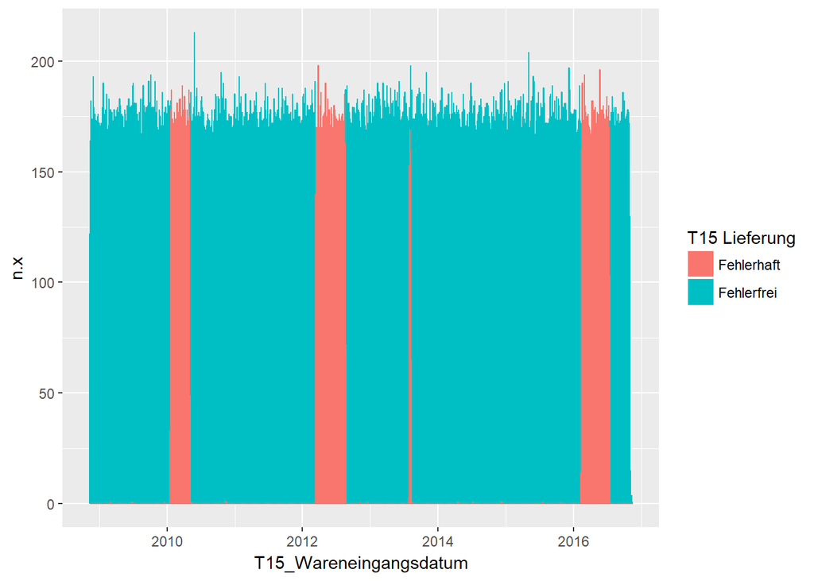

```r
#wie viele Einzelteile gab es zu welchem Wareneingangsdatum INSGESAMT
T15GC <- count(T15.new,T15_Wareneingangsdatum)

#wie viele Einzelteile waren zu welchem Wareneingangsdatum SCHLECHT
T15FC <- count(T15F,T15_Wareneingangsdatum)
T15CC <- left_join(T15GC,T15FC, by = "T15_Wareneingangsdatum")
T15CC[is.na(T15CC[,3]),3] <- 0

#Plot um Fehlerverlauf zu zeigen
ggplot(T15CC, aes(x = T15_Wareneingangsdatum))+
  geom_bar(stat = "identity",aes(y = n.x, col = "red", fill = "red"))+
  geom_bar(stat = "identity",aes(y = n.y, col = "blue", fill = "blue"))+
  scale_fill_discrete(name = "T15 Lieferung", labels = c("Fehlerhaft","Fehlerfrei"))+
  guides(color = FALSE)
```

#### T20

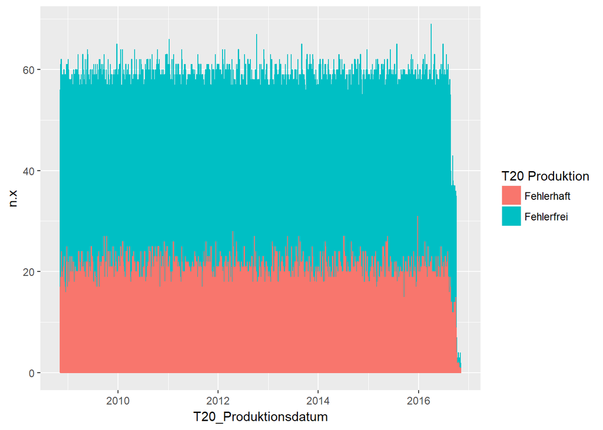

```r
#gleiches Vorgehen wie bei T15
T20GC <- count(T20.new,T20_Produktionsdatum)
T20FC <- count(T20F,T20_Produktionsdatum)
T20CC <- left_join(T20GC,T20FC, by = "T20_Produktionsdatum")
T20CC[is.na(T20CC[,3]),3] <- 0

#Plot um Fehlerverlauf zu zeigen
ggplot(T20CC, aes(x = T20_Produktionsdatum))+
  geom_bar(stat = "identity",aes(y = n.x, col = "red", fill = "red"))+
  geom_bar(stat = "identity",aes(y = n.y, col = "blue", fill = "blue"))+
  scale_fill_discrete(name = "T20 Produktion", labels = c("Fehlerhaft","Fehlerfrei"))+
  guides(color = FALSE)
```

### Lieferantenanalyse

Im Folgenden soll die Frage beantwortet werden, welche Lieferanten (Hersteller) unserem Unternehmen fehlerhafte Einzelteile geliefert haben.

Mit table() bestimmen wir die absoluten Häufigkeiten der Fehler pro Hersteller für die kritischen Einzelteile T15 und T20.

```r
table(T15F$T15_Herstellernummer)
```

```
##
##   209   210
## 34784 34866
```

```r
table(T20F$T20_Herstellernummer)
```

```
##
##   209   211
## 29032 19356
```

Der Hersteller 209 ist in die Produktion beider Einzelteile, die Hersteller 210 und 211 jeweils in die Produktion eines Einzelteils involviert.

Um herauszufinden, ob einer der jeweils zwei Hersteller in größerem Maße für die fehlerhaften Einzelteile verantwortlich ist, werden die vom Hersteller fehlerhaft zu den insgesamt produzierten Einzelteilen ins Verhältnis gesetzt.

```r
nrow(filter(T15F, T15_Herstellernummer == 209)) / nrow(filter(T15, Herstellernummer == 209))
```

```
## [1] 0.145829
```

```r
nrow(filter(T15F, T15_Herstellernummer == 210)) / nrow(filter(T15, Herstellernummer == 210))
```

```
## [1] 0.1461727
```

```r
nrow(filter(T20F, T20_Herstellernummer == 209)) / nrow(filter(T20, Herstellernummer == 209))
```

```
## [1] 0.295455
```

```r
nrow(filter(T20F, T20_Herstellernummer == 211)) / nrow(filter(T20, Herstellernummer == 211))
```

```
## [1] 0.2954844
```

Es ist ersichtlich, dass beide Hersteller jeweils in gleichem Maße für die Produktion fehlerhafter Teile verantwortlich sind.

Für die beteiligten Hersteller müsste eine Analyse des produzierenden Werkes durchgeführt werden, um herauszufinden, ob die Fehler nur in einem Werk oder über das gesamte Unternehmen verteilt auftreten. Da die Einzelteile aber jeweils nur in einem einzigen Werk produziert werden, erübrigt sich die Analyse.

## 3.Analyse der Komponenten

Es müssen alle Komponenten herausgefiltert werden, die beschädigt sind oder in denen fehlerhafte Teile verbaut sind.

### Import

```r
path.K2LE1B <- "Bestandteile_Komponente_K2LE1.csv"
path.K2LE2B <- "Bestandteile_Komponente_K2LE2.csv"
path.K2LE1 <- "Komponente_K2LE1.csv"
path.K2LE2 <- "Komponente_K2LE1.csv"

K2LE1B <- read.csv2(path.K2LE1B, stringsAsFactors = FALSE)
K2LE2B <- read.csv2(path.K2LE2B, stringsAsFactors = FALSE)
K2LE1 <- read.csv2(path.K2LE1, stringsAsFactors = FALSE)
K2LE2 <- read.csv2(path.K2LE2, stringsAsFactors = FALSE)
```

### Clean Data and Tidy Data

#### Struktur der Tabellen überprüfen

```r
#K2LE1B
firstGlance(K2LE1B)
```

```
##        X             ID_T11             ID_T14             ID_T15
##  Min.   :     1   Length:477052      Length:477052      Length:477052
##  1st Qu.:119264   Class :character   Class :character   Class :character
##  Median :238527   Mode  :character   Mode  :character   Mode  :character
##  Mean   :238527
##  3rd Qu.:357789
##  Max.   :477052
##    ID_K2LE1
##  Length:477052
##  Class :character
##  Mode  :character
##
##
##
##
## 'data.frame':    477052 obs. of  5 variables:
##  $ X       : int  1 2 3 4 5 6 7 8 9 10 ...
##  $ ID_T11  : chr  "11-215-2154-70" "11-215-2154-102" "11-212-2121-7" "11-212-2121-61" ...
##  $ ID_T14  : chr  "14-214-2142-8" "14-214-2142-11" "14-213-2132-1" "14-213-2132-5" ...
##  $ ID_T15  : chr  "15-209-2093-12" "15-209-2093-20" "15-210-2101-2" "15-210-2101-21" ...
##  $ ID_K2LE1: chr  "K2LE1-109-1091-1" "K2LE1-109-1091-2" "K2LE1-109-1091-3" "K2LE1-109-1091-4" ...
## NULL
##
##   X          ID_T11         ID_T14         ID_T15         ID_K2LE1
## 1 1  11-215-2154-70  14-214-2142-8 15-209-2093-12 K2LE1-109-1091-1
## 2 2 11-215-2154-102 14-214-2142-11 15-209-2093-20 K2LE1-109-1091-2
## 3 3   11-212-2121-7  14-213-2132-1  15-210-2101-2 K2LE1-109-1091-3
## 4 4  11-212-2121-61  14-213-2132-5 15-210-2101-21 K2LE1-109-1091-4
## 5 5  11-212-2121-95  14-213-2132-6 15-210-2101-24 K2LE1-109-1091-5
## 6 6 11-212-2121-153  14-213-2132-9  15-209-2093-6 K2LE1-109-1091-6
##
##             X             ID_T11             ID_T14             ID_T15
## 477047 477047 11-212-2121-712609  14-214-2142-55939 15-210-2101-237333
## 477048 477048 11-212-2121-712632  14-213-2132-92536 15-209-2093-237515
## 477049 477049 11-212-2121-712323  14-214-2142-54774 15-209-2093-237091
## 477050 477050 11-212-2121-712593 14-214-2143-169392 15-210-2101-237111
## 477051 477051 11-212-2121-712597  14-213-2132-94474 15-210-2101-238052
## 477052 477052 11-212-2121-712605  14-213-2131-92596 15-210-2101-236127
##                     ID_K2LE1
## 477047 K2LE1-111-1111-286227
## 477048 K2LE1-111-1111-286228
## 477049 K2LE1-111-1111-286229
## 477050 K2LE1-111-1111-286230
## 477051 K2LE1-111-1111-286231
## 477052 K2LE1-111-1111-286232
```

```r
NATest(K2LE1B)
```

```
## [1] "Es existieren keine NA´s."
```

```r
#K2LE2B
firstGlance(K2LE2B)
```

```
##       X.1               X             ID_T16             ID_T19
##  Min.   :     1   Min.   :     1   Length:163769      Length:163769
##  1st Qu.: 40943   1st Qu.: 40943   Class :character   Class :character
##  Median : 81885   Median : 81885   Mode  :character   Mode  :character
##  Mean   : 81885   Mean   : 81885
##  3rd Qu.:122827   3rd Qu.:122827
##  Max.   :163769   Max.   :163769
##     ID_T20            ID_K2LE2
##  Length:163769      Length:163769
##  Class :character   Class :character
##  Mode  :character   Mode  :character
##
##
##
##
## 'data.frame':    163769 obs. of  6 variables:
##  $ X.1     : int  1 2 3 4 5 6 7 8 9 10 ...
##  $ X       : int  1 2 3 4 5 6 7 8 9 10 ...
##  $ ID_T16  : chr  "16-213-2132-44" "16-215-2152-68" "16-212-2121-9" "16-212-2121-16" ...
##  $ ID_T19  : chr  "19-215-2154-4" "19-214-2143-3" "19-214-2143-6" "19-214-2143-9" ...
##  $ ID_T20  : chr  "20-209-2091-23" "20-211-2111-6" "20-211-2111-10" "20-211-2111-14" ...
##  $ ID_K2LE2: chr  "K2LE2-111-1111-1" "K2LE2-111-1111-2" "K2LE2-111-1111-3" "K2LE2-111-1111-4" ...
## NULL
##
##   X.1 X         ID_T16         ID_T19         ID_T20         ID_K2LE2
## 1   1 1 16-213-2132-44  19-215-2154-4 20-209-2091-23 K2LE2-111-1111-1
## 2   2 2 16-215-2152-68  19-214-2143-3  20-211-2111-6 K2LE2-111-1111-2
## 3   3 3  16-212-2121-9  19-214-2143-6 20-211-2111-10 K2LE2-111-1111-3
## 4   4 4 16-212-2121-16  19-214-2143-9 20-211-2111-14 K2LE2-111-1111-4
## 5   5 5 16-212-2121-19 19-214-2143-12  20-209-2091-1 K2LE2-111-1111-5
## 6   6 6 16-213-2132-29 19-214-2143-15  20-209-2091-3 K2LE2-111-1111-6
##
##           X.1      X             ID_T16            ID_T19
## 163764 163764 163764  16-212-2122-96688 19-214-2143-49093
## 163765 163765 163765 16-213-2132-161118 19-214-2143-46917
## 163766 163766 163766 16-212-2121-147381 19-214-2143-46220
## 163767 163767 163767 16-213-2132-161697 19-214-2143-48615
## 163768 163768 163768 16-213-2132-162083 19-214-2143-47637
## 163769 163769 163769 16-213-2132-163434 19-214-2143-47692
##                   ID_T20             ID_K2LE2
## 163764 20-209-2091-96178 K2LE2-109-1091-65502
## 163765 20-209-2091-96917 K2LE2-109-1091-65503
## 163766 20-209-2091-95888 K2LE2-109-1091-65504
## 163767 20-211-2111-63229 K2LE2-109-1091-65505
## 163768 20-209-2091-97757 K2LE2-109-1091-65506
## 163769 20-211-2111-64474 K2LE2-109-1091-65507
```

```r
NATest(K2LE2B)
```

```
## [1] "Es existieren keine NA´s."
```

```r
#K2LE1
firstGlance(K2LE1)
```

```
##        X            IDNummer         Produktionsdatum   Herstellernummer
##  Min.   :     1   Length:477052      Length:477052      Min.   :109.0
##  1st Qu.:119264   Class :character   Class :character   1st Qu.:109.0
##  Median :238527   Mode  :character   Mode  :character   Median :111.0
##  Mean   :238527                                         Mean   :110.2
##  3rd Qu.:357789                                         3rd Qu.:111.0
##  Max.   :477052                                         Max.   :111.0
##   Werksnummer     Fehlerhaft
##  Min.   :1091   Min.   :0.00e+00
##  1st Qu.:1091   1st Qu.:0.00e+00
##  Median :1111   Median :0.00e+00
##  Mean   :1103   Mean   :3.14e-05
##  3rd Qu.:1111   3rd Qu.:0.00e+00
##  Max.   :1111   Max.   :1.00e+00
##
## 'data.frame':    477052 obs. of  6 variables:
##  $ X               : int  1 2 3 4 5 6 7 8 9 10 ...
##  $ IDNummer        : chr  "K2LE1-109-1091-1" "K2LE1-109-1091-2" "K2LE1-109-1091-3" "K2LE1-109-1091-4" ...
##  $ Produktionsdatum: chr  "2008-11-12" "2008-11-12" "2008-11-13" "2008-11-13" ...
##  $ Herstellernummer: int  109 109 109 109 109 109 109 109 109 109 ...
##  $ Werksnummer     : int  1091 1091 1091 1091 1091 1091 1091 1091 1091 1091 ...
##  $ Fehlerhaft      : int  0 0 0 0 0 0 0 0 0 0 ...
## NULL
##
##   X         IDNummer Produktionsdatum Herstellernummer Werksnummer
## 1 1 K2LE1-109-1091-1       2008-11-12              109        1091
## 2 2 K2LE1-109-1091-2       2008-11-12              109        1091
## 3 3 K2LE1-109-1091-3       2008-11-13              109        1091
## 4 4 K2LE1-109-1091-4       2008-11-13              109        1091
## 5 5 K2LE1-109-1091-5       2008-11-13              109        1091
## 6 6 K2LE1-109-1091-6       2008-11-13              109        1091
##   Fehlerhaft
## 1          0
## 2          0
## 3          0
## 4          0
## 5          0
## 6          0
##
##             X              IDNummer Produktionsdatum Herstellernummer
## 477047 477047 K2LE1-111-1111-286227       2016-11-13              111
## 477048 477048 K2LE1-111-1111-286228       2016-11-13              111
## 477049 477049 K2LE1-111-1111-286229       2016-11-14              111
## 477050 477050 K2LE1-111-1111-286230       2016-11-14              111
## 477051 477051 K2LE1-111-1111-286231       2016-11-14              111
## 477052 477052 K2LE1-111-1111-286232       2016-11-14              111
##        Werksnummer Fehlerhaft
## 477047        1111          0
## 477048        1111          0
## 477049        1111          0
## 477050        1111          0
## 477051        1111          0
## 477052        1111          0
```

```r
NATest(K2LE1)
```

```
## [1] "Es existieren keine NA´s."
```

```r
#K2LE2
firstGlance(K2LE2)
```

```
##        X            IDNummer         Produktionsdatum   Herstellernummer
##  Min.   :     1   Length:477052      Length:477052      Min.   :109.0
##  1st Qu.:119264   Class :character   Class :character   1st Qu.:109.0
##  Median :238527   Mode  :character   Mode  :character   Median :111.0
##  Mean   :238527                                         Mean   :110.2
##  3rd Qu.:357789                                         3rd Qu.:111.0
##  Max.   :477052                                         Max.   :111.0
##   Werksnummer     Fehlerhaft
##  Min.   :1091   Min.   :0.00e+00
##  1st Qu.:1091   1st Qu.:0.00e+00
##  Median :1111   Median :0.00e+00
##  Mean   :1103   Mean   :3.14e-05
##  3rd Qu.:1111   3rd Qu.:0.00e+00
##  Max.   :1111   Max.   :1.00e+00
##
## 'data.frame':    477052 obs. of  6 variables:
##  $ X               : int  1 2 3 4 5 6 7 8 9 10 ...
##  $ IDNummer        : chr  "K2LE1-109-1091-1" "K2LE1-109-1091-2" "K2LE1-109-1091-3" "K2LE1-109-1091-4" ...
##  $ Produktionsdatum: chr  "2008-11-12" "2008-11-12" "2008-11-13" "2008-11-13" ...
##  $ Herstellernummer: int  109 109 109 109 109 109 109 109 109 109 ...
##  $ Werksnummer     : int  1091 1091 1091 1091 1091 1091 1091 1091 1091 1091 ...
##  $ Fehlerhaft      : int  0 0 0 0 0 0 0 0 0 0 ...
## NULL
##
##   X         IDNummer Produktionsdatum Herstellernummer Werksnummer
## 1 1 K2LE1-109-1091-1       2008-11-12              109        1091
## 2 2 K2LE1-109-1091-2       2008-11-12              109        1091
## 3 3 K2LE1-109-1091-3       2008-11-13              109        1091
## 4 4 K2LE1-109-1091-4       2008-11-13              109        1091
## 5 5 K2LE1-109-1091-5       2008-11-13              109        1091
## 6 6 K2LE1-109-1091-6       2008-11-13              109        1091
##   Fehlerhaft
## 1          0
## 2          0
## 3          0
## 4          0
## 5          0
## 6          0
##
##             X              IDNummer Produktionsdatum Herstellernummer
## 477047 477047 K2LE1-111-1111-286227       2016-11-13              111
## 477048 477048 K2LE1-111-1111-286228       2016-11-13              111
## 477049 477049 K2LE1-111-1111-286229       2016-11-14              111
## 477050 477050 K2LE1-111-1111-286230       2016-11-14              111
## 477051 477051 K2LE1-111-1111-286231       2016-11-14              111
## 477052 477052 K2LE1-111-1111-286232       2016-11-14              111
##        Werksnummer Fehlerhaft
## 477047        1111          0
## 477048        1111          0
## 477049        1111          0
## 477050        1111          0
## 477051        1111          0
## 477052        1111          0
```

```r
NATest(K2LE2)
```

```
## [1] "Es existieren keine NA´s."
```

```r
#IDNummer aufsplitten
K2LE2.sep <- K2LE2%>%
  separate(IDNummer, c("KK","Rest"),sep = "-", extra = "merge")

#Ersten Teil richtig benennen
K2LE2.sep$KK <- "K2LE2"
K2LE2.new <- unite(K2LE2.sep,col = IDNummer, KK, Rest, sep = "-")
```

### Kritische Komponenten

Anschließend werden alle Komponenten gefiltert, die fehlerhafte Einzelteile enthalten. Daraufhin werden alle Komponenten rausgefiltert, die auf Komponentenebene fehlerhaft sind.

#### Komponenten mit fehlerhaften Einzelteilen

##### Bestandteile_Komponenten-Datensätze mit fehlerhaften Einzelteile-Datensätze joinen

*Vorgehen:* Da K2LE1B aus T11, T14 und T15 und K2LE2B aus T16, T19 und T20 bestehen, werden jeweils neue Datensätze erstellt, bei denen die Bestandteile_Komponente-Datensätze nach den jeweiligen fehlerhaften Einzelteilen gefiltert werden.

```r
#K(omponente K2LE)1 J(oined with T)X

K1J11 <- select(K2LE1B,2:5)%>%
  inner_join(T11F,by = c("ID_T11" = "T11_IDNummer"))%>%
  left_join(select(T14.new,1:4), by= c("ID_T14" = "T14_IDNummer"))%>%
  left_join(select(T15.new,1:4), by= c("ID_T15" = "T15_IDNummer"))

K1J14 <- select(K2LE1B,2:5)%>%
  inner_join(T14F,by = c("ID_T14"= "T14_IDNummer"))%>%
  left_join(select(T11.new,1:4), by= c("ID_T11" = "T11_IDNummer"))%>%
  left_join(select(T15.new,1:4), by= c("ID_T15" = "T15_IDNummer"))

K1J15 <- select(K2LE1B,2:5)%>%
  inner_join(T15F,by = c("ID_T15"= "T15_IDNummer"))%>%
  left_join(select(T14.new,1:4), by= c("ID_T14" = "T14_IDNummer"))%>%
  left_join(select(T11.new,1:4), by= c("ID_T11" = "T11_IDNummer"))

#K(omponente K2LE)2 J(oined with T)X

K2J16 <- select(K2LE2B,3:6)%>%
  inner_join(T16F,by = c("ID_T16"= "T16_IDNummer"))%>%
  left_join(select(T19.new,1:4), by= c("ID_T19" = "T19_IDNummer"))%>%
  left_join(select(T20.new,1:4), by= c("ID_T20" = "T20_IDNummer"))

K2J19 <- select(K2LE2B,3:6)%>%
  inner_join(T19F,by = c("ID_T19"= "T19_IDNummer"))%>%
  left_join(select(T16.new,1:4), by= c("ID_T16" = "T16_IDNummer"))%>%
  left_join(select(T20.new,1:4), by= c("ID_T20" = "T20_IDNummer"))

K2J20 <- select(K2LE2B,3:6)%>%
  inner_join(T20F,by = c("ID_T20"= "T20_IDNummer"))%>%
  left_join(select(T19.new,1:4), by= c("ID_T19" = "T19_IDNummer"))%>%
  left_join(select(T16.new,1:4), by= c("ID_T16" = "T16_IDNummer"))
```

##### Zusammenführen aller Komponenten-Datensätze mit fehlerhaften Einzelteilen

Zusammenführen der neuen Datensätze, die zu einer Komponente gehören. Damit sind für Komponentenart 1 und 2 alle Komponenten-ID´s ermittelt, die fehlerhafte Einzelteile enthalten.

```r
#Komponente Full Join mit Einzelteilen
K1JF <- full_join(K1J11,K1J14)%>%
  full_join(K1J15)

K2JF <- full_join(K2J16,K2J19)%>%
  full_join(K2J20)
```

#### Fehlerhafte Komponenten

##### “Fehlerhafte Komponeten” mit “Komponten mit fehlerhaften Einzelteilen” joinen & Eigenschaften hinzufügen

*Vorgehen:* Um die fehlerhaften Komponenten-ID´s zu ermitteln, müssen die K2LE1 und K2LE2 Datensätze in der Spalte “Fehlerhaft” nach Einsen gefiltert werden. Um diese dann später mit den K1JF und K2JF joinen zu können, werden zuerst den Datensätzen K1JF und K2JF die Spalten “Produktionsdatum”, “Herstellernummer” & “Werksnummer”, die zu den Komponenten-ID´s mit fehlerhaften Einzelteilen gehören, hinzugefügt, damit sie die gleiche Struktur aufweisen wie die K2LE1 und K2LE2 Datensätze. K1Krit und K2Krit werden dabei erzeugt.

```r
#Die Spalten "Produktionsdatum", "Herstellernummer", "Werksnummer", die zu den Komponenten-ID´s mit fehlerhaften Einzelteilen gehören, hinzufügen
K1Krit <- left_join(select(K1JF,4),select(K2LE1,2:5), by = c("ID_K2LE1" = "IDNummer"))%>%
  #fehlerhafte Komponenten mit Komponenten mit fehlerhaften Einzelteilen joinen
  full_join(K2LE1[K2LE1$Fehlerhaft == 1,2:5],by = c("ID_K2LE1" = "IDNummer","Produktionsdatum", "Herstellernummer", "Werksnummer"))

#Die Spalten Einzelteil_Fehlerhaft und Komponente_Fehlerhaft indizieren, auf welcher Ebene der Fehler liegt
K1Krit$Einzelteil_Fehlerhaft <- 0
K1Krit$Einzelteil_Fehlerhaft[which(K1Krit$ID_K2LE1 %in% K1JF$ID_K2LE1)] <- 1
K1Krit$Komponente_Fehlerhaft <- 0
K1Krit$Komponente_Fehlerhaft[which(K1Krit$ID_K2LE1 %in% filter(K2LE1, Fehlerhaft == 1)$IDNummer)] <- 1

#Gleiches Vorgehen wie bei K1Krit
K2Krit <- left_join(select(K2JF,4),select(K2LE2.new,2:5), by = c("ID_K2LE2" = "IDNummer"))%>%
  full_join(K2LE2.new[K2LE2.new$Fehlerhaft == 1,2:5],by = c("ID_K2LE2" = "IDNummer","Produktionsdatum", "Herstellernummer", "Werksnummer"))

K2Krit$Einzelteil_Fehlerhaft <- 0
K2Krit$Einzelteil_Fehlerhaft[which(K2Krit$ID_K2LE2 %in% K2JF$ID_K2LE2)] <- 1
K2Krit$Komponente_Fehlerhaft <- 0
K2Krit$Komponente_Fehlerhaft[which(K2Krit$ID_K2LE2 %in% filter(K2LE2.new, Fehlerhaft == 1)$IDNummer)] <- 1
```

Die Anzahl der Fehler auf Komponentenebene wird betrachtet:

```r
nrow(filter(K1Krit, Komponente_Fehlerhaft == 1))
```

```
## [1] 15
```

```r
nrow(filter(K2Krit, Komponente_Fehlerhaft == 1))
```

```
## [1] 15
```

Die Anzahl der Fehler auf Komponentenebene ist so gering, dass sie als Zufallsfehler interpretiert werden können.

#### Kritische Komponenten gesamt

K1Krit und K2Krit zusammenfassen zu KKrit und Spaltennamen zur besseren Unterscheidung anpassen.

```r
KKrit <- full_join(K1Krit,K2Krit, by = c("ID_K2LE1" = "ID_K2LE2","Produktionsdatum", "Herstellernummer", "Werksnummer"))

KKrit$Einzelteil_Fehlerhaft <- map2_dbl(KKrit$Einzelteil_Fehlerhaft.x, KKrit$Einzelteil_Fehlerhaft.y, sum, na.rm = TRUE)
KKrit$Komponente_Fehlerhaft <- map2_dbl(KKrit$Komponente_Fehlerhaft.x, KKrit$Komponente_Fehlerhaft.y, sum,na.rm = TRUE)

#Auswahl relevanter Spalten
KKrit <- select(KKrit, Komponente_ID = ID_K2LE1, Komponente_Produktionsdatum = Produktionsdatum, Komponente_Herstellernummer = Herstellernummer, Komponente_Werksnummer = Werksnummer, Einzelteil_Fehlerhaft, Komponente_Fehlerhaft)
```

##### Datensatz auf Richtigkeit der Struktur überprüfen

```r
firstGlance(KKrit)
```

```
##  Komponente_ID      Komponente_Produktionsdatum
##  Length:118090      Length:118090
##  Class :character   Class :character
##  Mode  :character   Mode  :character
##
##
##
##  Komponente_Herstellernummer Komponente_Werksnummer Einzelteil_Fehlerhaft
##  Min.   :109.0               Min.   :1091           Min.   :0.0000
##  1st Qu.:109.0               1st Qu.:1091           1st Qu.:1.0000
##  Median :111.0               Median :1111           Median :1.0000
##  Mean   :110.4               Mean   :1105           Mean   :0.9998
##  3rd Qu.:111.0               3rd Qu.:1111           3rd Qu.:1.0000
##  Max.   :111.0               Max.   :1111           Max.   :1.0000
##  Komponente_Fehlerhaft
##  Min.   :0.000000
##  1st Qu.:0.000000
##  Median :0.000000
##  Mean   :0.000254
##  3rd Qu.:0.000000
##  Max.   :1.000000
##
## 'data.frame':    118090 obs. of  6 variables:
##  $ Komponente_ID              : chr  "K2LE1-109-1091-86107" "K2LE1-109-1091-180913" "K2LE1-109-1091-189017" "K2LE1-111-1111-68070" ...
##  $ Komponente_Produktionsdatum: chr  "2010-04-24" "2011-11-24" "2012-01-13" "2013-03-15" ...
##  $ Komponente_Herstellernummer: int  109 109 109 111 111 111 111 111 111 109 ...
##  $ Komponente_Werksnummer     : int  1091 1091 1091 1111 1111 1111 1111 1111 1111 1091 ...
##  $ Einzelteil_Fehlerhaft      : num  1 1 1 1 1 1 1 1 1 1 ...
##  $ Komponente_Fehlerhaft      : num  0 0 0 0 0 0 0 0 0 0 ...
## NULL
##
##           Komponente_ID Komponente_Produktionsdatum
## 1  K2LE1-109-1091-86107                  2010-04-24
## 2 K2LE1-109-1091-180913                  2011-11-24
## 3 K2LE1-109-1091-189017                  2012-01-13
## 4  K2LE1-111-1111-68070                  2013-03-15
## 5  K2LE1-111-1111-78535                  2013-05-18
## 6 K2LE1-111-1111-142270                  2014-06-13
##   Komponente_Herstellernummer Komponente_Werksnummer Einzelteil_Fehlerhaft
## 1                         109                   1091                     1
```

[output cut: 19 more lines]

```
## 118090 K2LE2-111-1111-257535                  2016-05-17
##        Komponente_Herstellernummer Komponente_Werksnummer
## 118085                         109                   1091
## 118086                         111                   1111
## 118087                         111                   1111
## 118088                         111                   1111
## 118089                         111                   1111
## 118090                         111                   1111
##        Einzelteil_Fehlerhaft Komponente_Fehlerhaft
## 118085                     0                     1
## 118086                     0                     1
## 118087                     0                     1
## 118088                     0                     1
## 118089                     0                     1
## 118090                     0                     1
```

```r
NATest(KKrit)
```

```
## [1] "Es existieren keine NA´s."
```

Keine Auffälligkeiten, außer dass Komponente_Produktionsdatum falschen Datentyp (character) hat -> Umwandlung in Datumsformat

```r
KKrit$Komponente_Produktionsdatum <- as.Date(KKrit$Komponente_Produktionsdatum, format = "%Y-%m-%d")
```

## 4.Analyse der Fahrzeuge

Aufgrund der Tatsache, dass wir als Hersteller von Ledersitzen nur an Fehlern auf Komponenten- und Einzelteilebene interessiert sind, werden die Fehler, die auf Fahrzeugebene liegen, nicht betrachtet.

### Import

```r
path.OEM11B <- "Bestandteile_Fahrzeuge_OEM1_Typ11.csv"
path.OEM12B <- "Bestandteile_Fahrzeuge_OEM1_Typ12.csv"
path.OEM21B <- "Bestandteile_Fahrzeuge_OEM2_Typ21.csv"
path.OEM22B <- "Bestandteile_Fahrzeuge_OEM2_Typ22.csv"
path.OEM11 <- "Fahrzeuge_OEM1_Typ11.csv"
path.OEM12 <- "Fahrzeuge_OEM1_Typ12.csv"
path.OEM21 <- "Fahrzeuge_OEM2_Typ21.csv"
path.OEM22 <- "Fahrzeuge_OEM2_Typ22.csv"

OEM11B <- read.csv2(path.OEM11B, stringsAsFactors = FALSE)
OEM12B <- read.csv2(path.OEM12B, stringsAsFactors = FALSE)
OEM21B <- read.csv2(path.OEM21B, stringsAsFactors = FALSE)
OEM22B <- read.csv2(path.OEM22B, stringsAsFactors = FALSE)
OEM11 <- read.csv2(path.OEM11, stringsAsFactors = FALSE)
OEM12 <- read.csv2(path.OEM12, stringsAsFactors = FALSE)
OEM21 <- read.csv2(path.OEM21, stringsAsFactors = FALSE)
OEM22 <- read.csv2(path.OEM22, stringsAsFactors = FALSE)
```

### Clean Data and Tidy Data

#### Vorbereitung der Tabellen

```r
#Aussschließen der ersten Spalte, da sie für unsere Analyse überflüssig ist
OEM11.new <- OEM11 %>%
  select(2:6)
OEM12.new <- OEM12 %>%
  select(2:6)
OEM21.new <- OEM21 %>%
  select(2:6)
OEM22.new <- OEM22 %>%
  select(2:6)

#Umbenennen der Spaltennamen, für eine eindeutige Unterscheidung in der finalen Gesamttabelle
  names(OEM11.new) <- paste0("Fahrzeug_",names(OEM11.new))
  names(OEM12.new) <- paste0("Fahrzeug_",names(OEM12.new))
  names(OEM21.new) <- paste0("Fahrzeug_",names(OEM21.new))
  names(OEM22.new) <- paste0("Fahrzeug_",names(OEM22.new))
```

### Fahrzeuge mit kritischen Komponenten

Mittels KKrit lassen sich nun die Fahrzeuge mit kritischen Komponeten identifizieren.

```r
OEM11F <- inner_join(OEM11B, KKrit, by = c("ID_Sitze" = "Komponente_ID"))%>%
  select(4,6:11)%>%
  left_join(select(OEM11.new,1:4),by = c("ID_Fahrzeug" = "Fahrzeug_IDNummer"))

OEM12F <- inner_join(OEM12B, KKrit, by = c("ID_Sitze" = "Komponente_ID"))%>%
  select(4,6:11)%>%
  left_join(select(OEM12.new,1:4),by = c("ID_Fahrzeug" = "Fahrzeug_IDNummer"))

OEM21F <- inner_join(OEM21B, KKrit, by = c("ID_Sitze" = "Komponente_ID"))%>%
  select(5,7:12)%>%
  left_join(select(OEM21.new,1:4),by = c("ID_Fahrzeug" = "Fahrzeug_IDNummer"))

OEM22F <- inner_join(OEM22B, KKrit, by = c("ID_Sitze" = "Komponente_ID"))%>%
  select(5,7:12)%>%
  left_join(select(OEM22.new,1:4),by = c("ID_Fahrzeug" = "Fahrzeug_IDNummer"))

#Autos gesamt, in denen Sitze feherhaft sind (durch fehlerhafte Komponenten oder Komponenten mit fehlerhaften Einzelteilen)
OEMF <- full_join(OEM11F,OEM12F)%>%
  full_join(OEM21F)%>%
  full_join(OEM22F)
```

#### Datensatz auf Richtigkeit der Struktur überprüfen

```r
firstGlance(OEMF)
```

```
##    ID_Sitze         ID_Fahrzeug        Komponente_Produktionsdatum
##  Length:118082      Length:118082      Min.   :2008-11-13
##  Class :character   Class :character   1st Qu.:2010-03-27
##  Mode  :character   Mode  :character   Median :2012-06-21
##                                        Mean   :2012-07-26
##                                        3rd Qu.:2013-07-11
##                                        Max.   :2016-10-16
##  Komponente_Herstellernummer Komponente_Werksnummer Einzelteil_Fehlerhaft
##  Min.   :109.0               Min.   :1091           Min.   :0.0000
##  1st Qu.:109.0               1st Qu.:1091           1st Qu.:1.0000
##  Median :111.0               Median :1111           Median :1.0000
##  Mean   :110.4               Mean   :1105           Mean   :0.9999
##  3rd Qu.:111.0               3rd Qu.:1111           3rd Qu.:1.0000
##  Max.   :111.0               Max.   :1111           Max.   :1.0000
##  Komponente_Fehlerhaft Fahrzeug_Produktionsdatum Fahrzeug_Herstellernummer
##  Min.   :0.0000000     Length:118082             Min.   :1.00
##  1st Qu.:0.0000000     Class :character          1st Qu.:1.00
##  Median :0.0000000     Mode  :character          Median :1.00
##  Mean   :0.0001863                               Mean   :1.41
##  3rd Qu.:0.0000000                               3rd Qu.:2.00
##  Max.   :1.0000000                               Max.   :2.00
##  Fahrzeug_Werksnummer
##  Min.   :11.00
##  1st Qu.:11.00
##  Median :12.00
##  Mean   :15.52
##  3rd Qu.:21.00
##  Max.   :22.00
##
## 'data.frame':    118082 obs. of  10 variables:
##  $ ID_Sitze                   : chr  "K2LE1-109-1091-7676" "K2LE1-109-1091-18002" "K2LE1-109-1091-37100" "K2LE1-109-1091-46188" ...
##  $ ID_Fahrzeug                : chr  "11-1-12-11043" "11-1-11-46275" "11-1-11-92198" "11-1-12-75191" ...
##  $ Komponente_Produktionsdatum: Date, format: "2008-12-30" "2009-03-04" ...
##  $ Komponente_Herstellernummer: int  109 109 109 109 109 109 109 109 109 109 ...
##  $ Komponente_Werksnummer     : int  1091 1091 1091 1091 1091 1091 1091 1091 1091 1091 ...
##  $ Einzelteil_Fehlerhaft      : num  0 1 1 0 1 1 1 0 1 1 ...
##  $ Komponente_Fehlerhaft      : num  1 0 0 1 0 0 0 1 0 0 ...
##  $ Fahrzeug_Produktionsdatum  : chr  "2009-01-07" "2009-03-14" "2009-07-06" "2009-09-03" ...
##  $ Fahrzeug_Herstellernummer  : int  1 1 1 1 1 1 1 1 1 1 ...
##  $ Fahrzeug_Werksnummer       : int  12 11 11 12 12 12 11 12 12 12 ...
```

[output cut: 51 more lines]

```
## 118082                     1                     0
##        Fahrzeug_Produktionsdatum Fahrzeug_Herstellernummer
## 118077                2016-11-12                         2
## 118078                2016-11-13                         2
## 118079                2016-11-16                         2
## 118080                2016-11-20                         2
## 118081                2016-11-20                         2
## 118082                2016-11-22                         2
##        Fahrzeug_Werksnummer
## 118077                   22
## 118078                   22
## 118079                   22
## 118080                   22
## 118081                   22
## 118082                   21
```

```r
NATest(OEMF)
```

```
## [1] "Es existieren keine NA´s."
```

Keine Auffälligkeiten, außer dass Fahrzeug_Produktionsdatum falschen Datentyp (character) hat -> Umwandlung in Datumsformat

```r
OEMF$Fahrzeug_Produktionsdatum <- as.Date(OEMF$Fahrzeug_Produktionsdatum, format = "%Y-%m-%d")
```

#### Wie viele Fahrzeuge enthalten fehlerhafte Sitze?

```r
nrow(OEMF)
```

```
## [1] 118082
```

118082 Fahrzeuge enthalten Sitze, die entweder auf Komponentenebene fehlerhaft sind oder aus fehlerhaften Einzelteilen bestehen. Es gilt, herauszufinden, wo und wann diese Fahrzeuge zugelassen wurden.

## 5.Zulassung & Geodaten

### Import

```r
Zul_aller <- read.csv2("Zulassungen_alle_Fahrzeuge.csv", stringsAsFactors = FALSE)
Geo <- read.csv2("Geodaten_Gemeinden.csv", stringsAsFactors = FALSE)
```

### Clean Data and Tidy Data

```r
#Auswählen relevanter Spalten, Ausschließen überflüssiger Spalten
Geo.new <- Geo%>%
  select(3:6)
Zul_aller.new <- Zul_aller%>%
  select(2:4)
```

### Finaler Datensatz

```r
GesTab <- left_join(OEMF,Zul_aller.new, by =c("ID_Fahrzeug" = "IDNummer"))%>%
  left_join(Geo.new, by = c("Gemeinden" = "Gemeinde"))
names(GesTab) <- c("ID_Sitze", "ID_Fahrzeug", "Komponente_Produktionsdatum", "Komponente_Herstellernummer", "Komponente_Werksnummer", "Einzelteil_Fehlerhaft", "Komponente_Fehlerhaft", "Fahrzeug_Produktionsdatum", "Fahrzeug_Herstellernummer", "Fahrzeug_Werksnummer", "Gemeinden", "Zulassung", "Postleitzahl", "Laengengrad", "Breitengrad")

firstGlance(GesTab)
```

```
##    ID_Sitze         ID_Fahrzeug        Komponente_Produktionsdatum
##  Length:118082      Length:118082      Min.   :2008-11-13
##  Class :character   Class :character   1st Qu.:2010-03-27
##  Mode  :character   Mode  :character   Median :2012-06-21
##                                        Mean   :2012-07-26
##                                        3rd Qu.:2013-07-11
##                                        Max.   :2016-10-16
##
##  Komponente_Herstellernummer Komponente_Werksnummer Einzelteil_Fehlerhaft
##  Min.   :109.0               Min.   :1091           Min.   :0.0000
##  1st Qu.:109.0               1st Qu.:1091           1st Qu.:1.0000
##  Median :111.0               Median :1111           Median :1.0000
##  Mean   :110.4               Mean   :1105           Mean   :0.9999
##  3rd Qu.:111.0               3rd Qu.:1111           3rd Qu.:1.0000
##  Max.   :111.0               Max.   :1111           Max.   :1.0000
##
##  Komponente_Fehlerhaft Fahrzeug_Produktionsdatum Fahrzeug_Herstellernummer
##  Min.   :0.0000000     Min.   :2008-11-19        Min.   :1.00
##  1st Qu.:0.0000000     1st Qu.:2010-12-12        1st Qu.:1.00
##  Median :0.0000000     Median :2012-07-25        Median :1.00
##  Mean   :0.0001863     Mean   :2013-02-20        Mean   :1.41
##  3rd Qu.:0.0000000     3rd Qu.:2016-01-29        3rd Qu.:2.00
##  Max.   :1.0000000     Max.   :2016-11-22        Max.   :2.00
##
##  Fahrzeug_Werksnummer  Gemeinden          Zulassung
##  Min.   :11.00        Length:118082      Length:118082
##  1st Qu.:11.00        Class :character   Class :character
##  Median :12.00        Mode  :character   Mode  :character
##  Mean   :15.52
##  3rd Qu.:21.00
##  Max.   :22.00
##
##   Postleitzahl    Laengengrad      Breitengrad
##  Min.   : 1067   Min.   : 5.902   Min.   :47.45
##  1st Qu.:26382   1st Qu.: 8.058   1st Qu.:49.30
##  Median :50667   Median : 9.937   Median :50.85
##  Mean   :50680   Mean   :10.021   Mean   :50.63
##  3rd Qu.:78476   3rd Qu.:11.882   3rd Qu.:51.67
##  Max.   :99998   Max.   :14.988   Max.   :54.87
##  NA's   :9       NA's   :9        NA's   :9
```

[output cut: 82 more lines]

```
## 118082                2016-11-22                         2
##        Fahrzeug_Werksnummer              Gemeinden  Zulassung Postleitzahl
## 118077                   22              IGERSHEIM 2016-12-19        97999
## 118078                   22              BIELEFELD 2016-12-21        33602
## 118079                   22                BAMBERG 2016-12-21        96047
## 118080                   22          KUEMMERSBRUCK 2016-12-22        92245
## 118081                   22            OBERHAUSEN1 2016-12-23        76887
## 118082                   21 PETERSHAGEN/EGGERSDORF 2016-12-27        15370
##        Laengengrad Breitengrad
## 118077    9.815731    49.49662
## 118078    8.532120    52.02058
## 118079   10.886786    49.89339
## 118080   11.877755    49.41933
## 118081    8.057771    49.09799
## 118082   13.815749    52.53771
```

```r
NATest(GesTab)
```

```
## [1] "9 NA´s in Postleitzahl"
## [1] "9 NA´s in Laengengrad"
## [1] "9 NA´s in Breitengrad"
```

- Zulassung hat falschen Datentyp (character) -> Umwandlung in Datumsformat
- NAs in Spalten “Postleitzahl”, “Laengengrad” und “Breitengrad” (betrifft die Gemeinde “Seeg”)

```r
#in Datumsformat umwandeln
GesTab$Zulassung <-  as.Date(GesTab$Zulassung, format = "%Y-%m-%d")

#Überprüfung, ob die Gemeinde "Seeg" Geodaten hat
Geo[Geo$Gemeinde == "SEEG",]
```

```
## [1] X.1          X            Postleitzahl Gemeinde     Längengrad
## [6] Breitengrad
## <0 rows> (or 0-length row.names)
```

Keine Geodaten für die Gemeinde “Seeg”.

```r
#Aus dem Internet PLZ und Werte für L. und B. Grade
GesTab$Postleitzahl[GesTab$Gemeinden == "SEEG"] <- 87637
GesTab$Laengengrad[GesTab$Gemeinden == "SEEG"] <- 10.6104157
GesTab$Breitengrad[GesTab$Gemeinden == "SEEG"] <- 47.6542215
```

### Visualisierung

#### Welche Fahrzeugtypen sind am meisten von den fehlerhaften Sitzen betroffen und welche Sitzart ist mehr fehlerhaft?

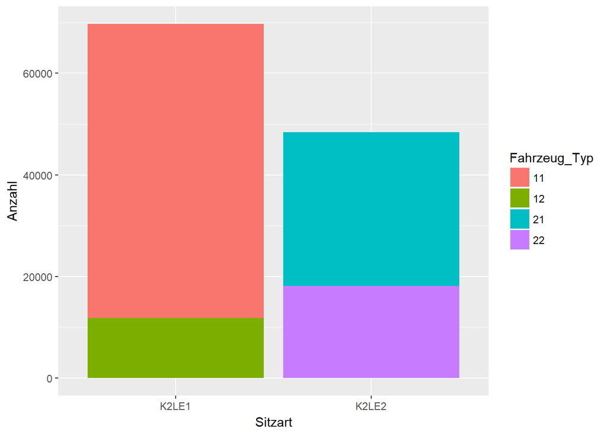

```r
#IDNummer aufsplitten
GesTab.sep <- GesTab%>%
  separate(ID_Sitze, c("Sitz_Art","Rest1"),sep = "-", remove = FALSE, extra = "merge")%>%
  separate(ID_Fahrzeug, c("Fahrzeug_Typ","Rest2"),sep = "-", remove = FALSE, extra = "merge")

GesTab.new <- GesTab.sep%>%
  select(1:2,4:5,7:19)

ggplot(GesTab.new, aes(x = Sitz_Art, fill = Fahrzeug_Typ))+
  geom_bar() +
  labs(x = "Sitzart", y = "Anzahl")
```

Daraus ist zu entnehmen, dass vermehrt Sitzart K2LE1 fehlerhaft ist und die Autos in folgender Häufigkeit betroffen sind: FT11 > FT21 > FT22 > FT12. (FT = Fahrzeugtyp)

#### Verteilung - Wann wurden Autos mit fehlerhaften Sitzen zugelasssen?

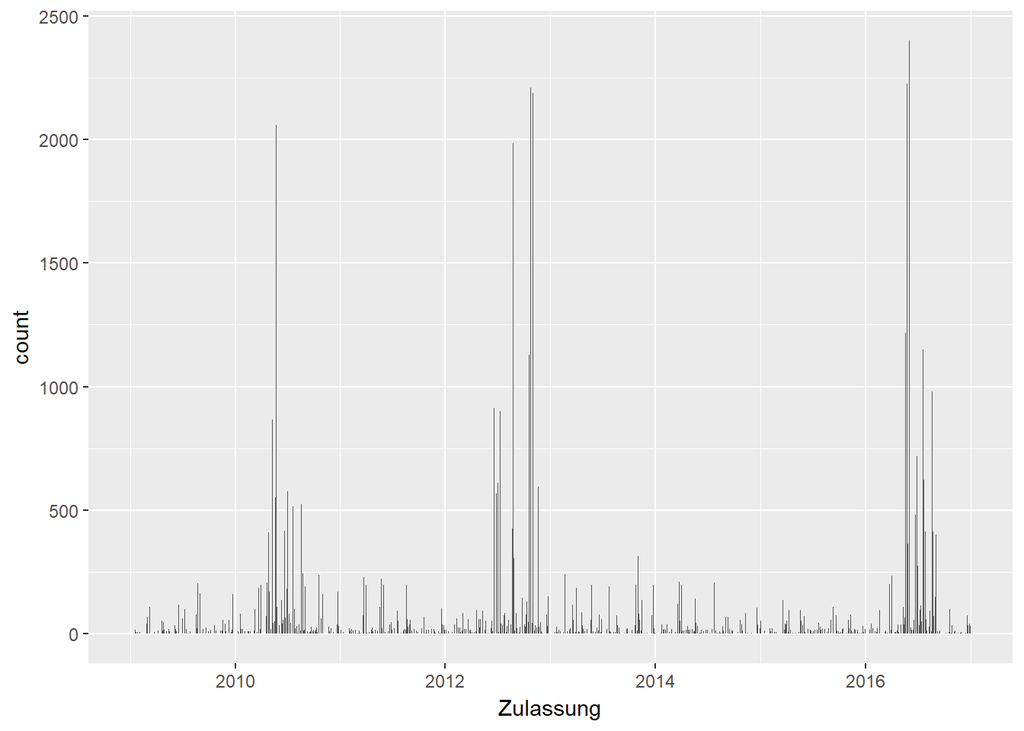

```r
ggplot(GesTab, aes(x = Zulassung))+
  geom_bar()
```

Die meisten Autos mit fehlerhaften Sitzen wurden folglich Mitte 2010, Mitte bis Ende 2012 und Mitte 2016 zugelassen.

#### Wo wurden Autos mit fehlerhaften Sitzen zugelassen?

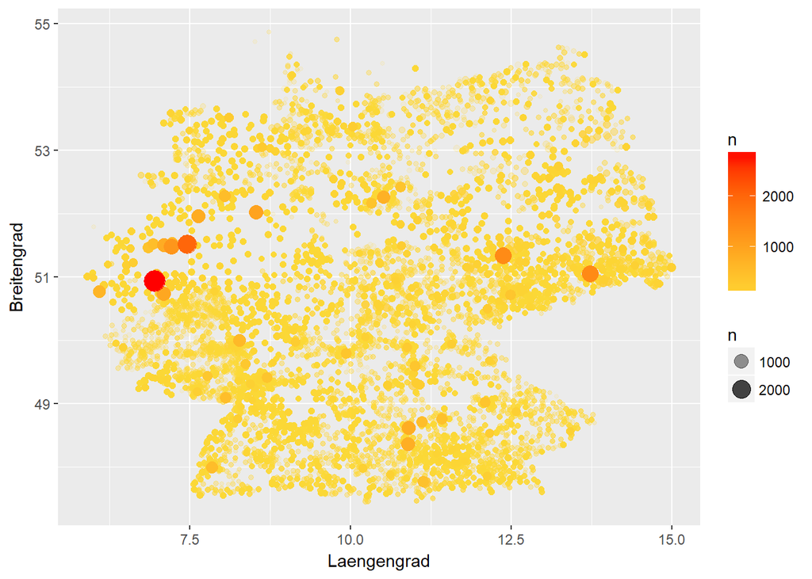

```r
GesTabCount <- count(GesTab.new, Postleitzahl)%>%
  left_join(GesTab.new, by ="Postleitzahl")%>%
  select(1:2,4,6,15:18)%>%
  arrange(n)

ggplot(GesTabCount, aes(x = Laengengrad, y = Breitengrad, colour = n, size = n, alpha = n))+
  geom_point()+
  scale_colour_gradient(low = "#ffd633", high = "red")
```

Zur Ermittlung von Zulassungsschwerpunkten werden die sechs Städte bestimmt, in denen die meisten mit fehlerhaften Elementen versehenen Fahrzeuge zugelassen wurden.

```r
zulassungsschwerpunkte <- GesTab.new %>%
  group_by(Gemeinden) %>%
  summarise(count = n()) %>%
  arrange(desc(count))
zulassungsschwerpunkte[1:6,]
```

```
## # A tibble: 6 x 2
##   Gemeinden count
##   <chr>     <int>
## 1 KOELN      2840
## 2 DORTMUND   2016
## 3 DRESDEN    1444
## 4 LEIPZIG    1419
## 5 BOCHUM     1236
## 6 BIELEFELD  1004
```

#### In welchen Gebieten sind welche Fahrzeugtypen betroffen?

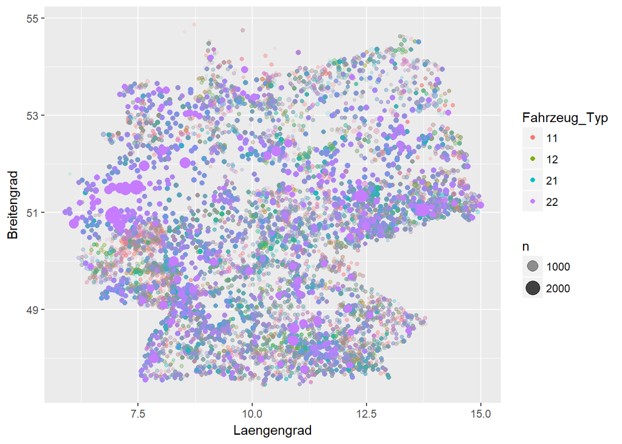

```r
ggplot(GesTabCount, aes(x = Laengengrad, y = Breitengrad, colour = Fahrzeug_Typ, size = n, alpha = n))+
  geom_point(position = position_jitter())
```

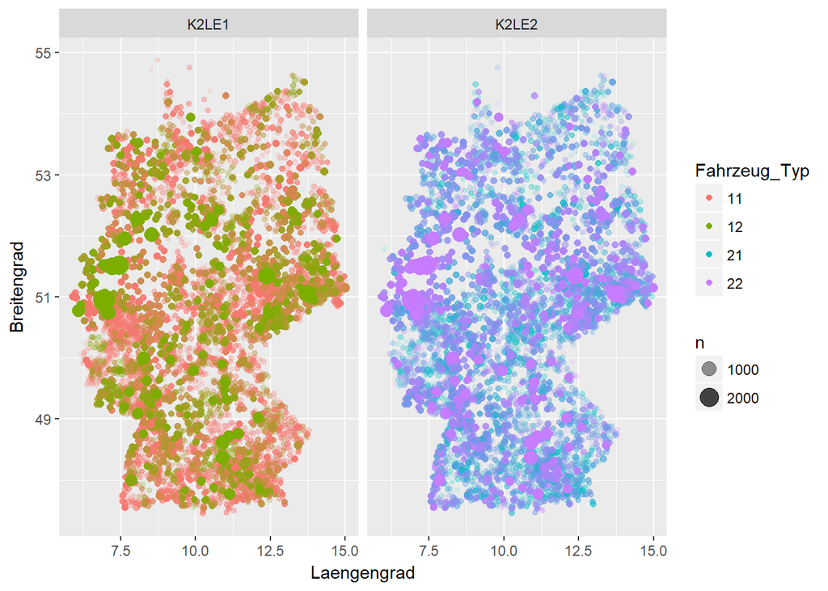

```r
#Unterscheidung in Sitz_Art 1 und 2
GesTabCount %>% filter(Fahrzeug_Typ %in% c("11", "12", "21", "22")) %>%
    ggplot(aes(x=Laengengrad, y=Breitengrad, color = Fahrzeug_Typ, group = Fahrzeug_Typ,size = n, alpha = n)) +
    geom_point() +
    facet_grid( ~ Sitz_Art)
```

## 6. Export des finalen Datensatzes

Um den finalen Datensatz in einer Shiny-App ansprechend zu visualisieren, wird dieser im RDS-Format gespeichert und in das R-Skript für die Shiny-App importiert.

```r
saveRDS(object = GesTab.new, file = "Case_Study_Datensatz.rds")
```